# KMeans Extended for Abstracted Distance Metrics

I have occasionally encountered problems where I want to use KMeans to cluster something by a metric other than euclidean. A common example is text data, which may have been one-hot encoded by n-grams, which is more appropriately analyzed with the cosine distance. Here I write such a class and try it out on text data.

```python
from sklearn.datasets import fetch_20newsgroups
import spacy
from sklearn.feature_extraction.text import TfidfVectorizer,CountVectorizer
from sklearn.metrics.pairwise import cosine_distances,euclidean_distances
import numpy as np
import pandas as pd
from sklearn.decomposition import PCA
import matplotlib.pyplot as plt
```

The sample data I'll use is the newsgroups dataset.

```python
newsgroups = fetch_20newsgroups(subset='all', categories=None, remove=('headers', 'footers', 'quotes'))
print(f"Number of documents: {len(newsgroups.data)}")
print(f"Categories: {newsgroups.target_names}")

print("\nSample Document:")
print(newsgroups.data[0])
```

```
Number of documents: 18846
Categories: ['alt.atheism', 'comp.graphics', 'comp.os.ms-windows.misc', 'comp.sys.ibm.pc.hardware', 'comp.sys.mac.hardware', 'comp.windows.x', 'misc.forsale', 'rec.autos', 'rec.motorcycles', 'rec.sport.baseball', 'rec.sport.hockey', 'sci.crypt', 'sci.electronics', 'sci.med', 'sci.space', 'soc.religi…

Sample Document:


I am sure some bashers of Pens fans are pretty confused about the lack
of any kind of posts about the recent Pens massacre of the Devils. Actually,
I am  bit puzzled too and a bit relieved. However, I am going to put an end
to non-PIttsburghers' relief with a bit of praise for the Pens. Man, they
are killing those Devils worse than I thought. Jagr just showed you why
he is much better than his regular season stats. He is also a lot
fo fun to watch in the playoffs. Bowman should let JAgr have a lot of
fun in the next couple of games since the Pens are going to beat the pulp out of Jersey anyway. I was very disappointed not to see the Islanders lose the final
regular season game.          PENS RULE!!!
```

I'll take stopwords from the spacy en_core_web_lg model. I prefer these stopwords to other sets that I've used.

```python
nlp = spacy.load("en_core_web_lg")
stop_words = nlp.Defaults.stop_words
```

```python
len(newsgroups['target'])
```

```
18846
```

```python
cleaned = ["".join([j for j in i if (j==' ')|(j.isalpha())|(j==".")]) for i in newsgroups['data']]
```

Here I'll begin to procedurally create the KMeans functionality, starting starting with vectorization of the text (which I've dropped special characters from above).

```python
vectorizer = TfidfVectorizer(max_features=10000,stop_words=list(stop_words),ngram_range=(1,1))
tfidf_matrix = vectorizer.fit_transform(cleaned)

# Ignore the warning. It's fine.
```

Here I'll specify k=8, and sample 8 points as the starting centroids. I'm not using any more intelligent init than this for now. I will however make sure all initial centroids have at least one datapoint in its cluster.

```python
k=8

all_clusts_represented = False

while not all_clusts_represented:
    sampled_indices = np.random.choice(tfidf_matrix.shape[0],size=k,replace=False)

    centroids = tfidf_matrix[sampled_indices]

    dists = cosine_distances(
        tfidf_matrix,
        centroids
    )
    argmins=dists.argmin(axis=1)

    all_clusts_represented = set(argmins)==set(range(8))
```

Here is the iterative process to optimize the clusters.

```python
for e in range(121):
    dists = cosine_distances(
        tfidf_matrix,
        centroids
    )
    argmins=dists.argmin(axis=1)

    new_centroids = []
    for c in range(k):
        row = tfidf_matrix[argmins==c].mean(axis=0)
        new_centroids.append(row)

    new_centroids = np.concat(new_centroids)

    print(e,(new_centroids-centroids).sum())

    if abs((new_centroids-centroids).sum())==0:
        centroids = np.asarray(new_centroids)
        break

    centroids = np.asarray(new_centroids)

dists = cosine_distances(tfidf_matrix,centroids)
argmins = dists.argmin(axis=1)
centroid_dist = dists[:,list(argmins)][:,0]
```

```
0 -1.8616937426154494
1 -1.0834990288596402
2 -0.4459789423283058
3 0.0025238333623424786
4 -0.01441651162243228
5 0.07102507802894925
6 0.03574892191705854
7 0.005085984693613942
8 -0.04256522190299117
9 -0.05709255954142689
10 -0.06759084766642656
11 -0.03838524761577418
12 -0.010738272710643756
13 -0.011203747638138044
14 0.0016130647073447897
```

[output cut: 70 more lines]

Having developed the procedure, here I'll wrap it in an SKLearn base class.

```python
from sklearn.base import BaseEstimator,ClusterMixin

class KMeansExtended(BaseEstimator,ClusterMixin):

    def __init__(
        self,
        n_clusters=5,
        metric='cosine',
        epochs=100,
        verbose=False
    ):

        self.n_clusters=n_clusters
        self.epochs=epochs
        self.metric = metric
        self.verbose = verbose

        if metric=='cosine':
            self.metric_fn = cosine_distances
        else:
            self.metric_fn = euclidean_distances


    def fit(self,X,y=None):
        """Compute k-means clustering.

        Parameters
        ----------
        X : {array-like, sparse matrix} of shape (n_samples, n_features)
            Training instances to cluster.

        y : Ignored
            Not used, present here for API consistency by convention.

        Returns
        -------
        self : object
            Fitted estimator.
        """

        all_clusts_represented = False

        while not all_clusts_represented:
            sampled_indices = np.random.choice(X.shape[0],size=self.n_clusters,replace=False)

            self.cluster_centers_ = X[sampled_indices]
            dists = cosine_distances(
                X,
                self.cluster_centers_
            )
            argmins=dists.argmin(axis=1)

            all_clusts_represented = set(argmins)==set(range(self.n_clusters))

        for e in range(self.epochs):

            dists = self.metric_fn(
                X,
                self.cluster_centers_
            )
            argmins=dists.argmin(axis=1)

            new_centroids = []
            for c in range(self.n_clusters):
                row = tfidf_matrix[argmins==c].mean(axis=0)
                new_centroids.append(row)

            new_centroids = np.concat(new_centroids)
            if self.verbose:
                print(e,(new_centroids-self.cluster_centers_).sum())

            if abs((new_centroids-self.cluster_centers_).sum())==0:
                self.cluster_centers_ = np.asarray(new_centroids)
                break

            self.cluster_centers_ = np.asarray(new_centroids)

        dists = self.metric_fn(
            X,
            self.cluster_centers_
        )
        self.labels_ = dists.argmin(axis=1)

        return self

    def predict(self,X):
        """Predict the closest cluster each sample in X belongs to.

        Parameters
        ----------
        X : {array-like, sparse matrix} of shape (n_samples, n_features)
            New data to predict.

        Returns
        -------
        labels : ndarray of shape (n_samples,)
            Index of the cluster each sample belongs to.
        """

        dists = self.metric_fn(
            X,
            self.cluster_centers_
        )
        labels = dists.argmin(axis=1)

        return labels
```

```python
kmeans = KMeansExtended(n_clusters=20,metric='cosine',epochs=100)
kmeans.fit(tfidf_matrix)
```

```
KMeansExtended(n_clusters=20)
```

```python
kmeans_df = pd.DataFrame(
    {
        'data':cleaned,
        'target':newsgroups['target'],
        'cluster':kmeans.predict(tfidf_matrix)
    }
)
```

```python
kmeans_df
```

|  | data | target | cluster |
| --- | --- | --- | --- |
| 0 | I am sure some bashers of Pens fans are pretty... | 10 | 1 |
| 1 | My brother is in the market for a highperforma... | 3 | 14 |
| 2 | Finally you said what you dream about. Mediter... | 17 | 15 |
| 3 | ThinkIts the SCSI card doing the DMA transfers... | 3 | 14 |
| 4 | I have an old Jasmine drive which I cannot... | 4 | 14 |
| ... | ... | ... | ... |
| 18841 | DN From nyedacnsvax.uwec.edu David NyeDN A neu... | 13 | 8 |
| 18842 | Not in isolated ground recepticles usually an ... | 12 | 12 |
| 18843 | I just installed a DX CPU in a clone motherboa... | 3 | 14 |
| 18844 | Wouldnt this require a hypersphere. In space ... | 1 | 17 |
| 18845 | After a tip from Gary Crum crumfcom.cc.utah.ed... | 7 | 12 |

18846 rows × 3 columns

Let's perform PCA, and graph over two components, coloring by cluster, and also inspect what types of documents are in each cluster.

```python
pca = PCA(n_components=2)
Xpca = pca.fit_transform(tfidf_matrix)
kmeans_df[['PCA1','PCA2']]=Xpca
kmeans_df['NAMES'] = kmeans_df['target'].map({i:j for i,j in enumerate(newsgroups['target_names'])})
```

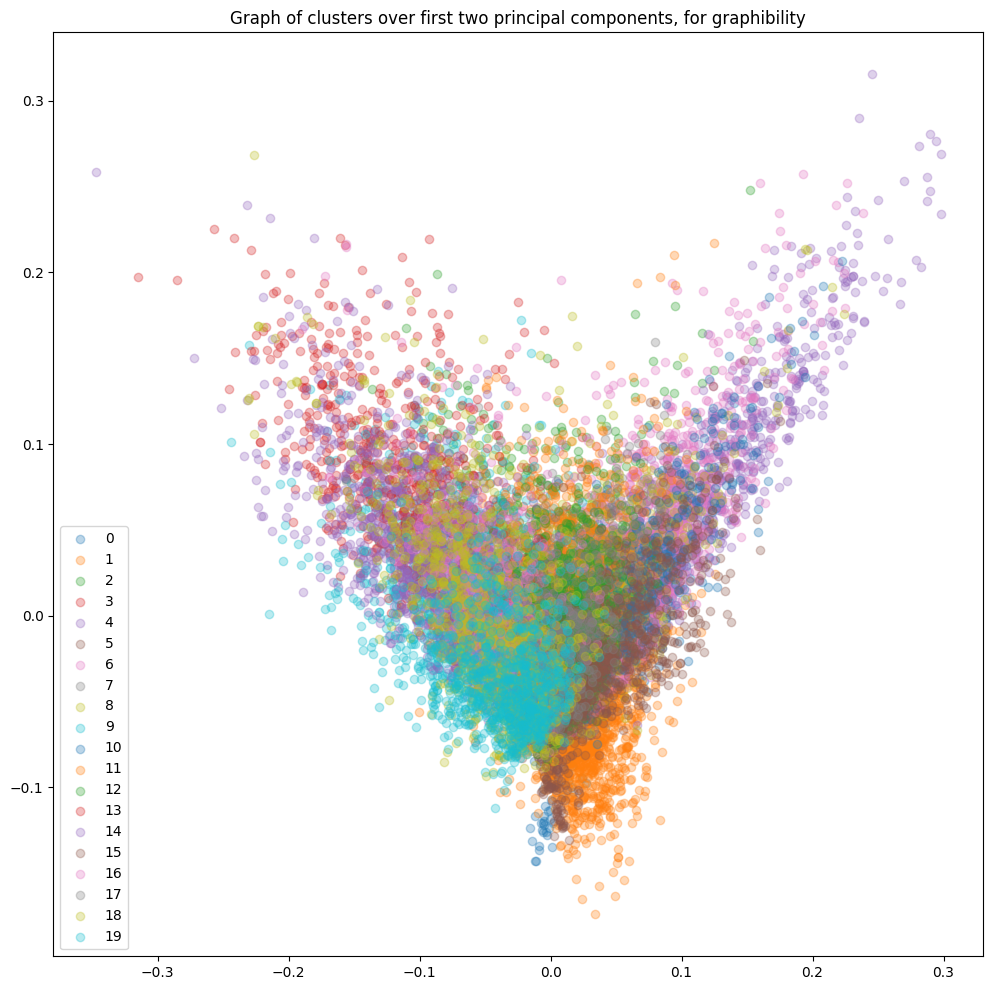

```python
fig = plt.figure(figsize=(12,12))

for c in range(20):
    tmp = kmeans_df[kmeans_df['cluster']==c].copy()
    plt.scatter(tmp['PCA1'],tmp['PCA2'],label=c,alpha=.3)
plt.title("Graph of clusters over first two principal components, for graphibility")
plt.legend()
plt.show()
```

```python
for i in range(20):
    print("\nCluster:\n",i,"\n")
    print(kmeans_df[kmeans_df['cluster']==i].groupby(['NAMES'])['cluster'].count().sort_values(ascending=False)[:3])
```

```
Cluster:
 0

NAMES
talk.politics.mideast    327
sci.med                  104
rec.sport.baseball        63
Name: cluster, dtype: int64

Cluster:
 1

NAMES
rec.sport.hockey      640
rec.sport.baseball    562
misc.forsale           18
Name: cluster, dtype: int64

Cluster:
 2

NAMES
sci.electronics    80
rec.motorcycles    72
comp.graphics      65
Name: cluster, dtype: int64

Cluster:
 3

NAMES
comp.sys.mac.hardware       95
sci.electronics             70
comp.sys.ibm.pc.hardware    60
Name: cluster, dtype: int64

Cluster:
 4

NAMES
```

[output cut: 124 more lines]

```

NAMES
comp.graphics              275
comp.windows.x             136
comp.os.ms-windows.misc    128
Name: cluster, dtype: int64

Cluster:
 19

NAMES
misc.forsale             516
comp.sys.mac.hardware     72
sci.electronics           46
Name: cluster, dtype: int64
```

There are some notible associations within clusters, while multiple clusters can have significant commonalities between them. Here I created 20 clusters, knowing the data has 20 classes. Multiple tech, sports and politics clusters emerge, while miscellaneous topics are spread amongst the formed clusters, probably due to some non-specific language.